# finans_ex1

Silje Marie Anfindsen

september 2021

# Oppgaver til første samling

## oppgave 1)

Gjør dere kjent med dataene, se på tidsseriene, sammenlign volatilitet og andre karakteristika så som hvordan serienes variasjon varierer over tid…og prøv å si noe om det relative forholdet mellom dem - og hva det kan skyldes. For å gjøre det litt morsomt for dere selv - IKKE prøv å matche tidsseriene med tilgjengelige børsserier…da får dere ikke brynet dere på samme måten. Men knytt gjerne skifter i variasjonsmønster til kjente datoer/perioder..

Hvor lenge skal man se på volatilitet over?

historisk er utrolig lavi forhold til forventet volatilitet på 15-20 prosent.

```r
# read in the first worksheet from the workbook myexcel.xlsx
mydata <- read.xlsx("aksjedata.xlsx", 1)
```

```r
manipulateSeries <- function(serie){

  date <- serie[,1]
  value <- serie[,2]

  if(is.na(tail(date,1))){
  end <- min(which(is.na(date)))-1
  df <- data.frame(date = date[1:end], value = value[1:end] )
  }
  else {
    df <- data.frame(date = date, value = value)
  }
  return(df)
}
```

```r
serie1 <- manipulateSeries(mydata[1:2])
serie2 <- manipulateSeries(mydata[3:4])
serie3 <- manipulateSeries(mydata[5:6])
serie4 <- manipulateSeries(mydata[7:8])
serie5 <- manipulateSeries(mydata[9:10])
serie6 <- manipulateSeries(mydata[11:12])
serie7 <- manipulateSeries(mydata[13:14])
serie8 <- manipulateSeries(mydata[15:16])
volatilitets.index <- manipulateSeries(mydata[17:18])
```

```r
series <- list(serie1, serie2, serie3, serie4, serie5, serie6, serie7, serie8, volatilitets.index)

findReturn <- function(serie){
  prices <- serie[,2]
  returns = rep(0, length(prices))
  returns[2:length(prices)] = (prices[-1]-prices[-length(prices)])/prices[-length(prices)]*100
  return(returns)
}
returns <- lapply(series, findReturn)
```

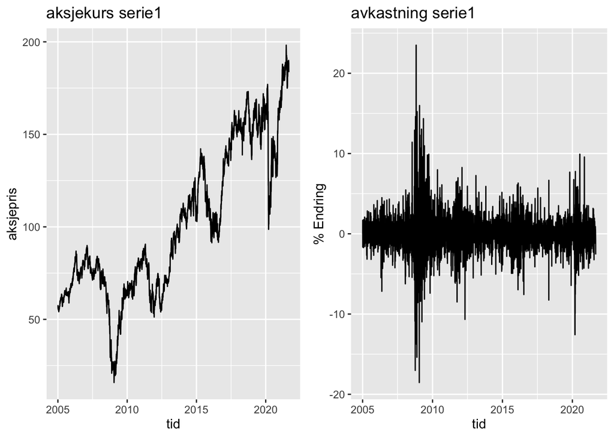

```r
g11 <- ggplot(data = serie1, mapping = aes(x=date , y=value )) + geom_line() + ggtitle("aksjekurs serie1") + labs(x="tid", y = "aksjepris")
g12 <- ggplot(data = serie1, mapping = aes(x=date, y=returns[[1]]) )  + geom_line() + ggtitle("avkastning serie1") + labs(x="tid", y="% Endring")
ggarrange(g11,g12)
```

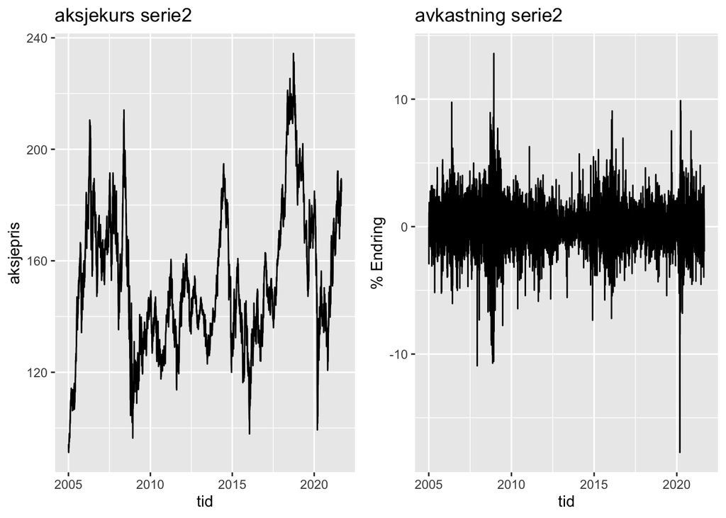

```r
g21 <- ggplot(data = serie2, mapping = aes(x=date , y=value )) + geom_line() + ggtitle("aksjekurs serie2") + labs(x="tid", y = "aksjepris")
g22 <- ggplot(data = serie2, mapping = aes(x=date, y=returns[[2]]) )  + geom_line() + ggtitle("avkastning serie2") + labs(x="tid", y="% Endring")
ggarrange(g21,g22)
```

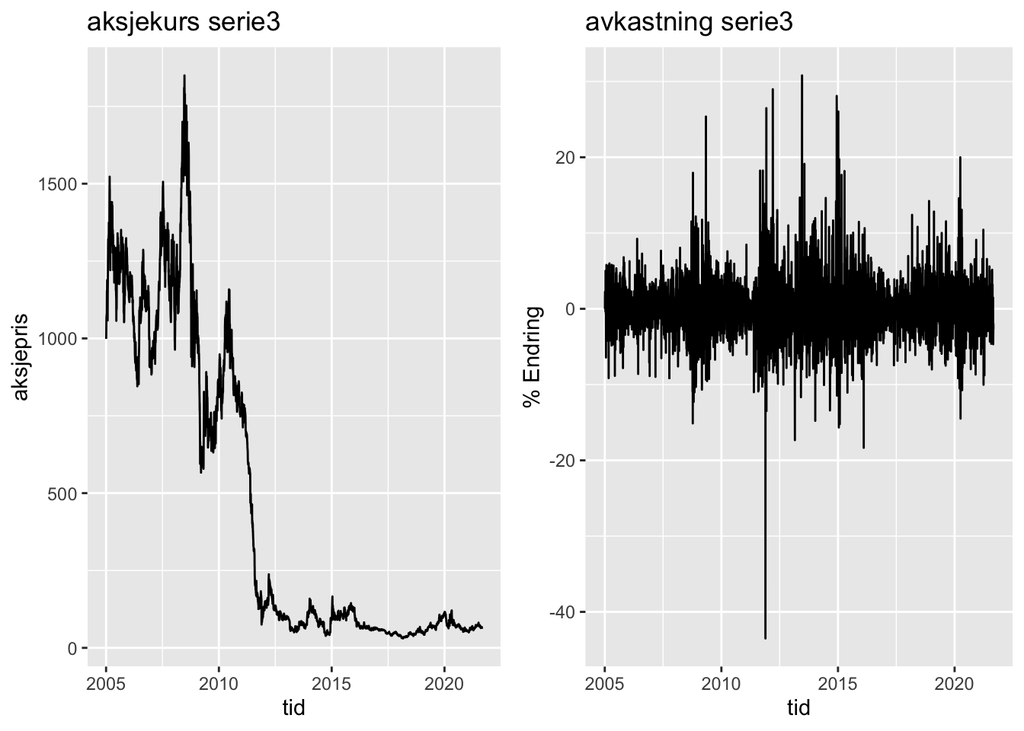

```r
g31 <- ggplot(data = serie3, mapping = aes(x=date , y=value )) + geom_line() + ggtitle("aksjekurs serie3") + labs(x="tid", y = "aksjepris")
g32 <- ggplot(data = serie3, mapping = aes(x=date, y=returns[[3]]) )  + geom_line() + ggtitle("avkastning serie3") + labs(x="tid", y="% Endring")
ggarrange(g31,g32)
```

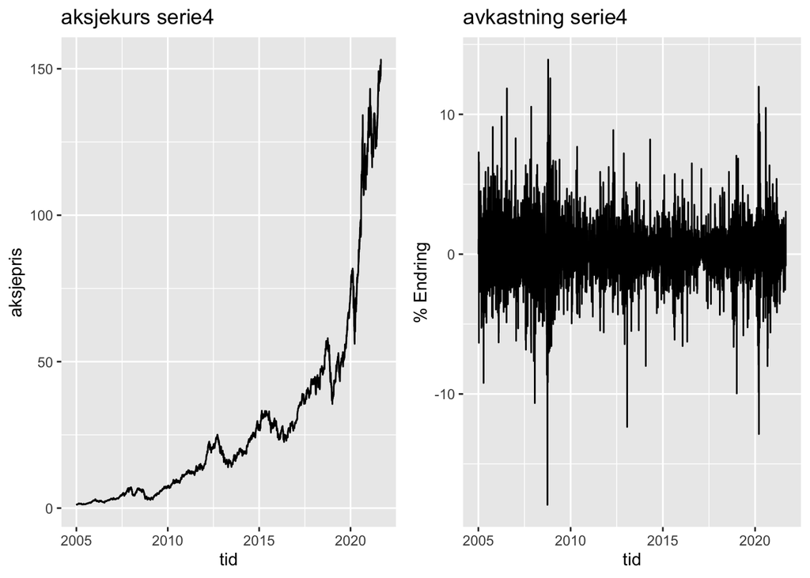

```r
g41 <- ggplot(data = serie4, mapping = aes(x=date , y=value )) + geom_line() + ggtitle("aksjekurs serie4") + labs(x="tid", y = "aksjepris")
g42 <- ggplot(data = serie4, mapping = aes(x=date, y=returns[[4]]) )  + geom_line() + ggtitle("avkastning serie4") + labs(x="tid", y="% Endring")
ggarrange(g41,g42)
```

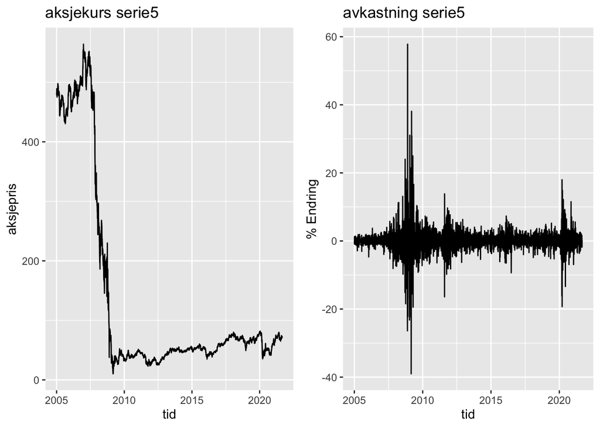

```r
g51 <- ggplot(data = serie5, mapping = aes(x=date , y=value )) + geom_line() + ggtitle("aksjekurs serie5") + labs(x="tid", y = "aksjepris")
g52 <- ggplot(data = serie5, mapping = aes(x=date, y=returns[[5]]) )  + geom_line() + ggtitle("avkastning serie5") + labs(x="tid", y="% Endring")
ggarrange(g51,g52)
```

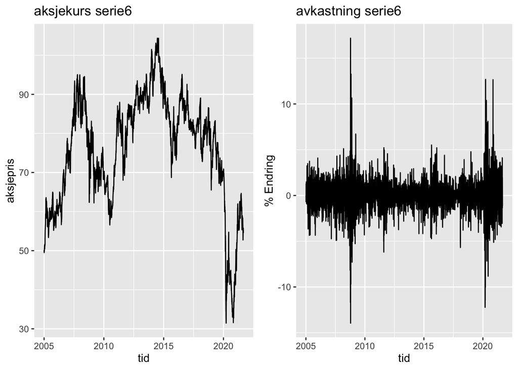

```r
g61 <- ggplot(data = serie6, mapping = aes(x=date , y=value )) + geom_line() + ggtitle("aksjekurs serie6") + labs(x="tid", y = "aksjepris")
g62 <- ggplot(data = serie6, mapping = aes(x=date, y=returns[[6]]) )  + geom_line() + ggtitle("avkastning serie6") + labs(x="tid", y="% Endring")
ggarrange(g61,g62)
```

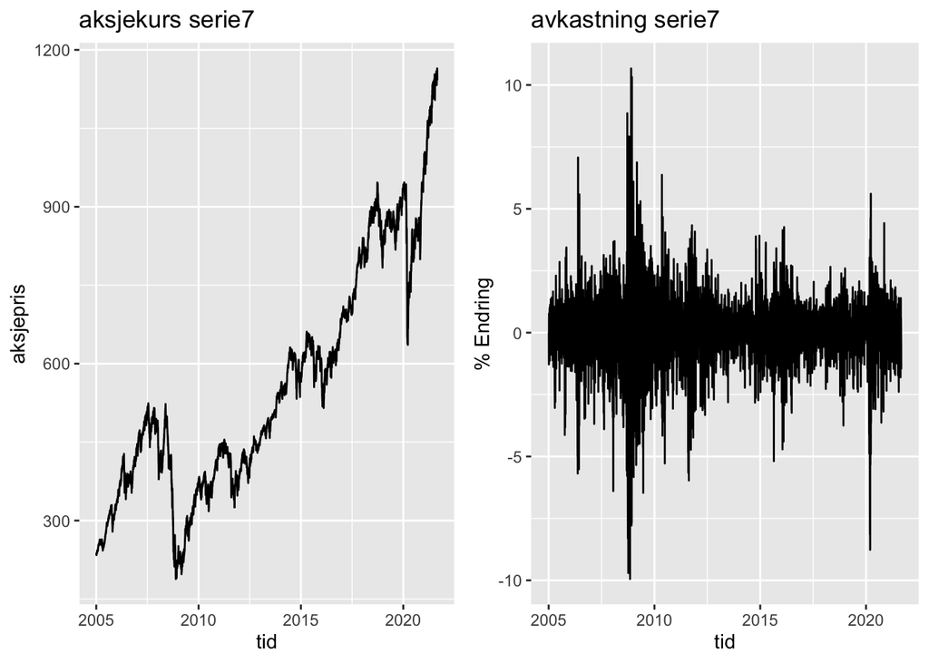

```r
g71 <- ggplot(data = serie7, mapping = aes(x=date , y=value )) + geom_line() + ggtitle("aksjekurs serie7") + labs(x="tid", y = "aksjepris")
g72 <- ggplot(data = serie7, mapping = aes(x=date, y=returns[[7]]) )  + geom_line() + ggtitle("avkastning serie7") + labs(x="tid", y="% Endring")
ggarrange(g71,g72)
```

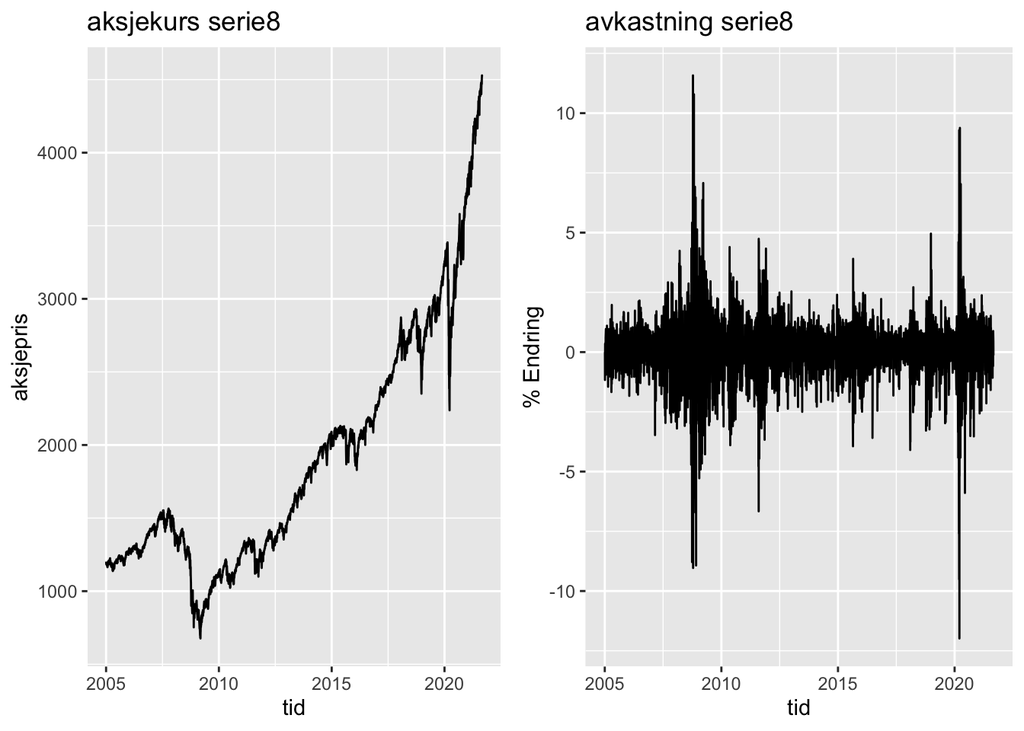

```r
g81 <- ggplot(data = serie8, mapping = aes(x=date , y=value )) + geom_line() + ggtitle("aksjekurs serie8") + labs(x="tid", y = "aksjepris")
g82 <- ggplot(data = serie8, mapping = aes(x=date, y=returns[[8]]) )  + geom_line() + ggtitle("avkastning serie8") + labs(x="tid", y="% Endring")
ggarrange(g81,g82)
```

serie1: indeks?

serie2: equinor

serie3: frontline

serie4: apple

serie5: amerikansk bank,

serie6: Exon

serie7:dnb?

serie8:indeks

### Knytt gjerne skifter i variasjonsmønster til kjente datoer/perioder:

2008-2009: finanskrisen

2011-2012: Statsgjeldskrisen som rammet Europa og USA?. Asia, Afrika, Latinamerika klarte seg godt.

2020-2021: korona

effekt av utbytte: kanskje den synker litt i verdi, brått en eller to ganger hvert år (systematisk fall)

## oppgave 2

Velg ut to eller flere av de seks tidsseriene til venstre og velg en måte å implementere en random walk modell for disse med utgangspunkt i dataseriene. Kommenter hvordan modellen passer med tidsseriene ved å se på faktiske inkrementer vs. modellfordelingen, qq-plot el.l. Gjør det samme for en av de neste to tidsseriene mot høyre (serie 7 og 8 fra venstre).

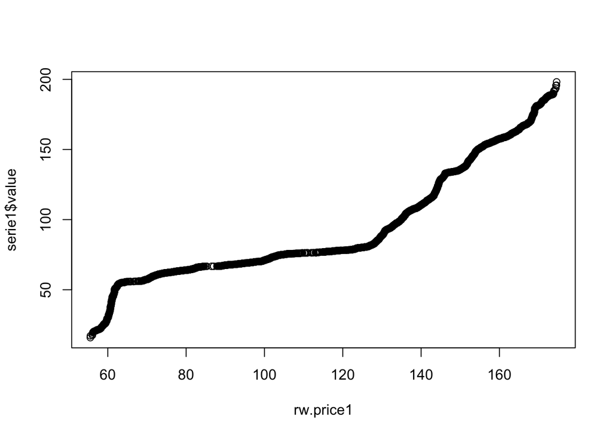

```r
#random walk
set.seed(123)

random.walk <- function(serie){
  days =  length(serie[,1])
  mu = mean(serie[,2])/days
  sigma = sd(serie[,2])*1/sqrt(days)
  p0 = serie[1,2]

  r = rnorm(days, mu, sigma)
  price <- p0 + cumsum(r)

  return (price)

}

rw.price1 <- random.walk(serie1)
rw.serie1 <- ggplot(data=serie1, aes(x=date,y=rw.price1)) + geom_line() + ggtitle("random walk") + labs(x="tid", y="simulert aksjepris")
qqplot(rw.price1, serie1$value)
```

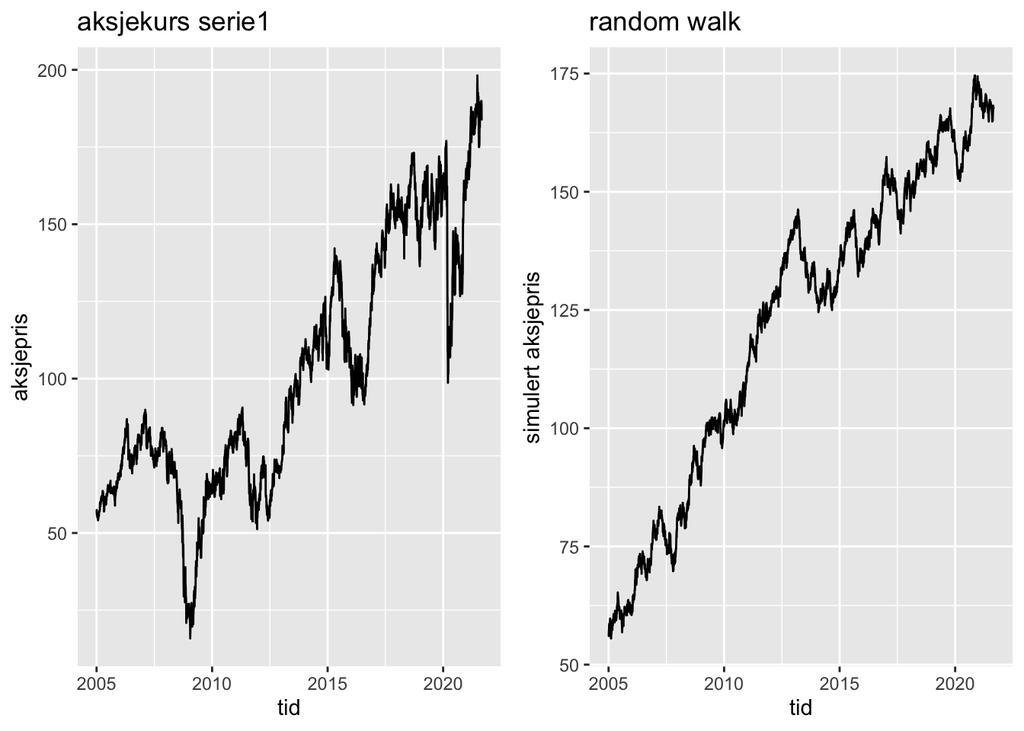

```r
ggarrange(g11, rw.serie1)
```

[figure not shown]

```r
rw.serie2 <- random.walk(serie2)
ggarrange(g21, rw.serie2)
```

[figure not shown]

```r
rw.serie7 <- random.walk(serie7)
ggarrange(g71, rw.serie7)
```

[figure not shown]

```r
rw.serie8 <- random.walk(serie8)
ggarrange(g81, rw.serie8)
```